# Availability of Blood Banks in various States

**This project deals with the exploratory analysis of the NFHS-3 and NFHS-4 data set by setting out research questions, and then exploring relationship between variables to answer those questions.**

Access to health care, and utilization of health care, is increasingly being identified as one of the most pressing challenges to the health care system, and by extending health policy, in many developing as well as some developed nations. This analysis is taking place against the background of increasing recognition of health as a human right, an important component of development and one of the main dimension and factors in overall wellbeing.

## Part 1: Data Set

#### Load packages

```r
library(ggplot2)
library(dplyr)
```

#### Load data

```r
myData2 <- read.csv(file='C:\\Users\\Shivang Keshari\\Downloads\\multi\\myFile2.csv', header=TRUE)

myData2_tot <- myData2 %>% filter(Dist=="Total")

myData2_tot <- myData2_tot %>%
          mutate(sum_c = (A+B+C+D+E))

myData2_tot <- myData2_tot %>% filter(States!="All India/ Total")

myData1 <- read.csv(file='C:\\Users\\Shivang Keshari\\Downloads\\multi\\myFile1.csv', header=TRUE)

myData1_st <- myData1 %>% filter(S_No!="India")

ind_rec <- myData1 %>% filter(Ind_St == "India")

max_pub <- myData1_st %>% filter(Pub_total == max(myData1_st$Pub_total))

min_pub <- myData1_st %>% filter(Pub_total == min(myData1_st$Pub_total))

max_pri <- myData1_st %>% filter(Pri_total == max(myData1_st$Pri_total))

min_pri <- myData1_st %>% filter(Pri_total == min(myData1_st$Pri_total))

myData3 <- read.csv(file='C:\\Users\\Shivang Keshari\\Downloads\\multi\\myFile3.csv', header=TRUE)

st_cou <- count(myData3, State)

max_st <- st_cou %>% filter(n == max(st_cou$n))

min_st <- st_cou %>% filter(n == min(st_cou$n))
```

## Part 2: Research Questions

**Research quesion 5:**

What is the current status of the availibilty of blood banks in India?

## Part 3: Data Analysis

**Interrogation 5:**

What is the current status of the availibilty of blood banks in India?

**SIGNIFICANCE**

Blood donations in India are conducted by several organizations and hospitals by organizing blood donation camps. Donors can also visit blood banks in hospitals to donate blood or directly to a receiver. Despite shortage of donated blood, efforts by the government and various organizations have led to a decrease in the demand and supply gap over the years. The number of voluntary blood donors increased from 54.4% in 2006-2007 to 83.1% in 2011-2012, with the number of blood units increasing from 4.4 million units in 2006-2007 to 9.3 million units in 2012-2013. In 2016, the Ministry of Health and Family Welfare reported a donation of 10.9 million units against a requirement of 12 million units.

Blood donors in India donate around 350 millilitres of blood. After a donation, the donors are provided with refreshments, which usually include a glucose drink, biscuits and fruits. Some organizations offer transportation facilities, apart from providing certificates or badges as a gratitude.

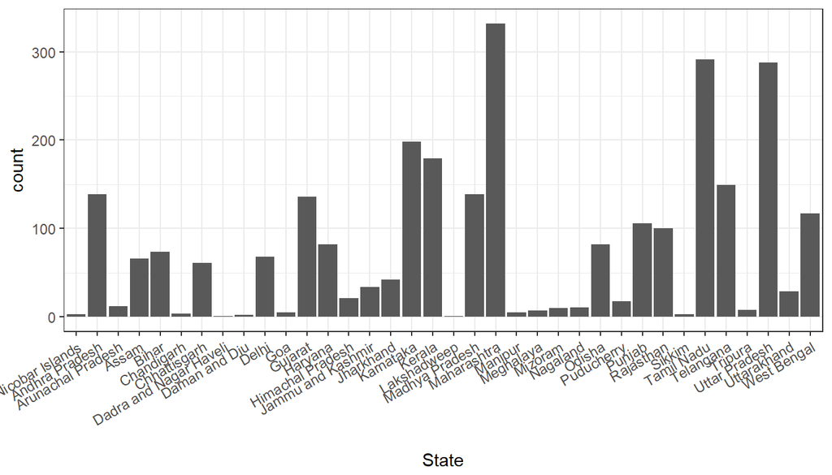

```r
ggplot(data = myData3, aes(x = State)) +
geom_bar()+
theme_bw() +
theme(axis.text.x = element_text(angle = 30, hjust = 1))
```

**EXPLANATION**

This bar graph shows the total number of Licensed blood banks in our nation. Maharashtra is having the higgest number of blood banks and the total being **332**,while Lakshwadweep and Dadra and Nagar haveli having the lowest with just **1** blood bank. Since , Maharashtra being the bigger state both in population as well as area, there is no comparison between the heavily populated Maharashtra and the small union territories of Lakshwadweep and Dadra and Nagar Haveli.

```r
cat(sprintf("\"%s\" \"%f\"\n", max_st$State[1], max_st$n[1]))
```

```
## "Maharashtra" "332.000000"
```

```r
cat(sprintf("\"%s\" \"%f\"\n", min_st$State, min_st$n))
```

```
## "Dadra and Nagar Haveli" "1.000000"
##  "Lakshadweep" "1.000000"
```